# HoneyBadger on Karaayvaz et al 2018

Ariel Madrigal

2020-November-17

## Loading libraries

```r
library(HoneyBADGER)
library(biomaRt)
library(pheatmap)
library(uwot)
library(ggfortify)
```

## Loading data

Reading data from GEO.

```r
exp_norm<- read.table("data/RSEM_TPM_240_NormalCells.txt")
exp_cancer<- read.table("data/GSE118389_tpm_rsem.txt")
meta_celltypes<- read.table("data/cell_types_tab_S9.txt", stringsAsFactors = FALSE, row.names=2)
meta_celltypes[,1]<- NULL
dim(meta_celltypes)
```

```
[1] 1112    1
```

```r
names(meta_celltypes)<- "cell"
length(intersect(rownames(meta_celltypes), colnames(exp_cancer)))
```

```
[1] 1112
```

Taking a look at the data

```r
dim(exp_norm)
```

```
[1] 23368   240
```

```r
head(exp_norm[,1:10])
```

|  | AACCAACCTGC | AACCAACGGTT | AACCAACTGAC | AACCAGAACCA | AACCATAACGT | AACCGAGAGCA | AACCGAGTCAG | AACCGCCATAT | AACCGCGCAGG | AACCGCTTCAA |
| --- | --- | --- | --- | --- | --- | --- | --- | --- | --- | --- |
| 1/2-SBSRNA4 | 0.18 | 0.00 | 0 | 41.46 | 0 | 0 | 0 | 0 | 0.32 | 0 |
| A1BG | 0.00 | 0.00 | 0 | 0.00 | 0 | 0 | 0 | 0 | 0.00 | 0 |
| A1BG-AS1 | 0.00 | 0.00 | 0 | 0.00 | 0 | 0 | 0 | 0 | 0.00 | 0 |
| A1CF | 0.00 | 0.00 | 0 | 0.00 | 0 | 0 | 0 | 0 | 0.00 | 0 |
| A2LD1 | 0.00 | 0.00 | 0 | 0.00 | 0 | 0 | 0 | 0 | 0.00 | 0 |
| A2M | 2.00 | 2.35 | 2 | 0.00 | 3 | 0 | 0 | 13 | 1796.58 | 0 |

```r
dim(exp_cancer)
```

```
[1] 21785  1534
```

```r
head(exp_cancer[,1:10])
```

|  | PT089_P1_A01 | PT089_P1_A02 | PT089_P1_A03 | PT089_P1_A04 | PT089_P1_A05 | PT089_P1_A06 | PT089_P1_A07 | PT089_P1_A08 | PT089_P1_A09 | PT089_P1_A10 |
| --- | --- | --- | --- | --- | --- | --- | --- | --- | --- | --- |
| A1BG | 0.00 | 0 | 0 | 0.00 | 0 | 0.00 | 0.00 | 0.00 | 0 | 224.88 |
| A1BG-AS1 | 0.00 | 0 | 0 | 0.00 | 0 | 0.00 | 0.00 | 0.00 | 0 | 0.00 |
| A1CF | 0.00 | 0 | 0 | 0.41 | 0 | 0.00 | 0.00 | 0.00 | 0 | 0.00 |
| A2M | 0.00 | 0 | 0 | 281.39 | 0 | 0.00 | 0.00 | 0.00 | 0 | 0.00 |
| A2M-AS1 | 0.00 | 0 | 0 | 0.00 | 0 | 0.00 | 0.00 | 0.00 | 0 | 0.00 |
| A2ML1 | 0.25 | 0 | 0 | 0.00 | 0 | 0.11 | 0.31 | 0.53 | 0 | 0.00 |

```r
exp_cancer<- exp_cancer[, rownames(meta_celltypes)]
```

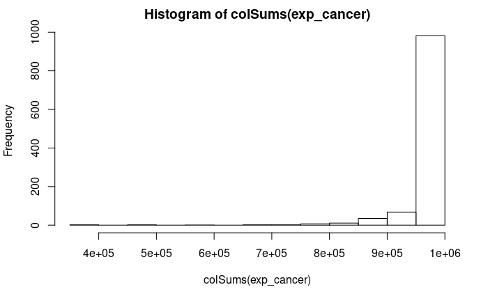

```r
hist(colSums(exp_cancer))
```

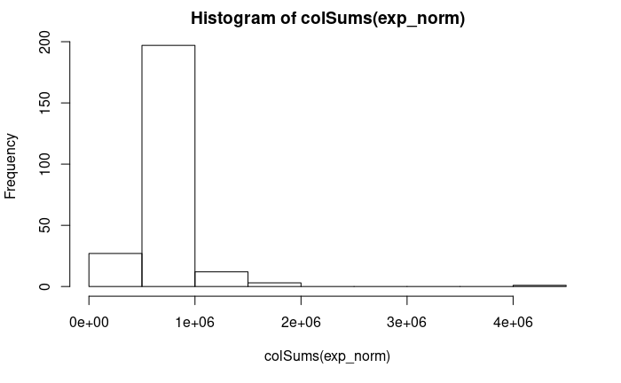

```r
hist(colSums(exp_norm))
```

## Filtering for genes

In this case we are going to use a TPM filter of 10 for both the reference and test datasets.

```r
mean_gene_norm<-rowMeans(exp_norm)
summary(mean_gene_norm)
```

```
    Min.  1st Qu.   Median     Mean  3rd Qu.     Max.
    0.00     0.01     1.34    30.80    14.81 45114.25
```

```r
length(which(mean_gene_norm> 10))
```

```
[1] 7221
```

```r
exp_norm<- exp_norm[mean_gene_norm>10,]
```

```r
mean_gene_cancer<- rowMeans(exp_cancer)
summary(mean_gene_cancer)
```

```
     Min.   1st Qu.    Median      Mean   3rd Qu.      Max.
    0.000     0.375     5.749    44.176    25.944 21644.406
```

```r
length(which(mean_gene_cancer> 10))
```

```
[1] 9041
```

```r
exp_cancer<- exp_cancer[mean_gene_cancer>10,]
```

```r
inter_genes<- intersect(rownames(exp_cancer), rownames(exp_norm))
length(inter_genes)
```

```
[1] 5560
```

```r
exp_cancer<- exp_cancer[inter_genes,]
exp_norm <- exp_norm[inter_genes,]
```

## Generating UMAP of the data

```r
set.seed(43)
sce_cells_umap <- umap(t(exp_cancer),
                       n_components = 2,
                       #a=1,
                       #b=0.6,
                       min_dist=0.01,
                       metric="cosine",
                       verbose = TRUE,
                       n_threads = max(1, RcppParallel::defaultNumThreads()/2) )
colnames(sce_cells_umap)<- c("UMAP1", "UMAP2")
rownames(sce_cells_umap)<- colnames(exp_cancer)
sce_cells_umap<- cbind(sce_cells_umap, meta)

head(sce_cells_umap)
```

|  | UMAP1 | UMAP2 | patient | plate | well | cell |
| --- | --- | --- | --- | --- | --- | --- |
| PT089_P1_A01 | 0.5538283 | 5.460897 | PT089 | P1 | A01 | epithelial |
| PT089_P1_A02 | 0.4698032 | 5.313827 | PT089 | P1 | A02 | epithelial |
| PT089_P1_A03 | 0.4478316 | 5.291798 | PT089 | P1 | A03 | epithelial |
| PT089_P1_A04 | 7.4599853 | -4.104423 | PT089 | P1 | A04 | macrophage |
| PT089_P1_A05 | 7.3335481 | -3.796718 | PT089 | P1 | A05 | macrophage |
| PT089_P1_A06 | 0.4591347 | 5.320779 | PT089 | P1 | A06 | epithelial |

```r
NA
```

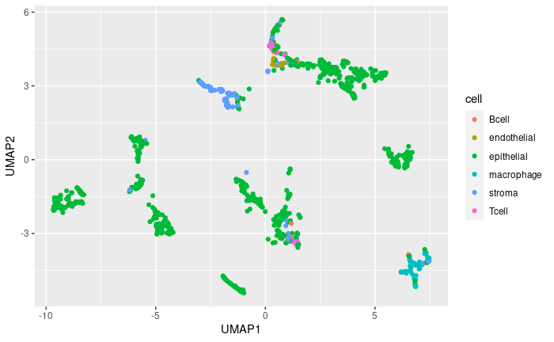

```r
ggplot(sce_cells_umap, aes(UMAP1, UMAP2, color=cell) )+
  geom_point()
```

## Creating meta data

```r
meta<- data.frame( row.names=colnames(exp_cancer),
                   patient= sapply(colnames(exp_cancer), function(X) unlist( strsplit(X, "_"))[1]),
                   plate= sapply(colnames(exp_cancer), function(X) unlist( strsplit(X, "_"))[2]),
                   well = sapply(colnames(exp_cancer), function(X) unlist( strsplit(X, "_"))[3]),
                   stringsAsFactors=FALSE)
length(intersect(rownames(meta), rownames(meta_celltypes)))
```

```
[1] 1112
```

```r
meta<- cbind(meta, meta_celltypes)
head(meta)
```

|  | patient | plate | well | cell |
| --- | --- | --- | --- | --- |
| PT089_P1_A01 | PT089 | P1 | A01 | epithelial |
| PT089_P1_A02 | PT089 | P1 | A02 | epithelial |
| PT089_P1_A03 | PT089 | P1 | A03 | epithelial |
| PT089_P1_A04 | PT089 | P1 | A04 | macrophage |
| PT089_P1_A05 | PT089 | P1 | A05 | macrophage |
| PT089_P1_A06 | PT089 | P1 | A06 | epithelial |

```r
NA
```

## Running HoneyBadger analysis for PT039

```r
mart.obj <- useMart(biomart = "ensembl", dataset = 'hsapiens_gene_ensembl', host = "feb2014.archive.ensembl.org") ## version used in manuscript
```

```r
PT039_meta<- meta[meta$patient  == "PT039",]
## Subsetting cells
set.seed(43)
#cells_keep<- sample(rownames(PT039_meta), 100)
cells_keep<- rownames(PT039_meta)
PT039_meta<- PT039_meta[cells_keep,]
head(PT039_meta)
```

|  | patient | plate | well | cell |
| --- | --- | --- | --- | --- |
| PT039_P11_A01_S1 | PT039 | P11 | A01 | epithelial |
| PT039_P11_A02_S2 | PT039 | P11 | A02 | epithelial |
| PT039_P11_A03_S3 | PT039 | P11 | A03 | epithelial |
| PT039_P11_A04_S4 | PT039 | P11 | A04 | epithelial |
| PT039_P11_A07_S7 | PT039 | P11 | A07 | epithelial |
| PT039_P11_A09_S9 | PT039 | P11 | A09 | epithelial |

```r
PT039_exp<- exp_cancer[,cells_keep]
```

Making a new HoneyBadger object

```r
hb <- new('HoneyBADGER', name='PT039')

hb$setGexpMats(log2(as.matrix(PT039_exp)+1), log2(exp_norm+1), mart.obj, filter=FALSE, scale=TRUE, verbose=TRUE)
```

```
Initializing expression matrices ...
Scaling coverage ...
Normalizing gene expression for 5560 genes and 273 cells ...
```

[output not shown]

```
Done setting initial expression matrices!
```

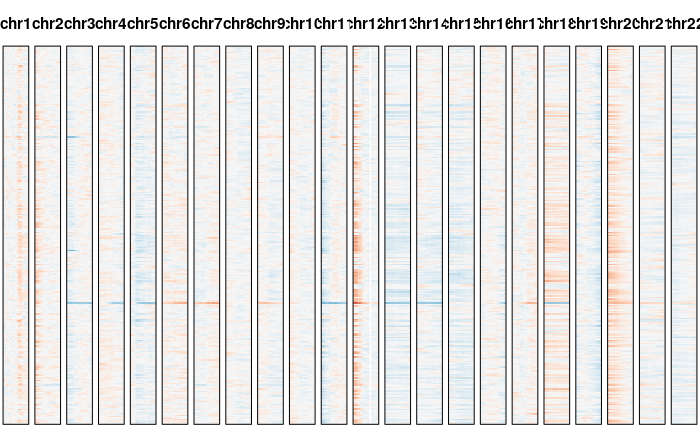

```r
hb$plotGexpProfile() ## initial visualization
```

```r
hb$setMvFit(verbose=TRUE) ## model variance
```

```
Modeling expected variance ... Done!
```

```r
hb$setGexpDev(verbose=TRUE) ## model necessary expression deviation to identify CNVs
```

```
Optimal deviance: 0.6496971
```

```r
hb$calcGexpCnvBoundaries(init=TRUE, verbose=FALSE) ## HMM
```

```
Linked to JAGS 4.3.0
Loaded modules: basemod,bugs
```

Double check what CNVs were identified

```r
bgf <- hb$bound.genes.final
genes <- hb$genes
regions.genes <- range(genes[unlist(bgf)])
print(regions.genes)
```

[output not shown]

The initial HMM step identified a number of candidate CNVs to test.

Now, we can use the bayesian model to derive the final posterior probability of each CNV in each cell.

Indeed, our initial HMM has identified a number of candidate CNVs to test. We can now retest all identified CNVs on all cells to derive the final posterior probability of each CNV in each cell.

```r
hb$retestIdentifiedCnvs(retestBoundGenes = TRUE, retestBoundSnps = FALSE, verbose=FALSE)
```

```r
## look at final results
results <- hb$summarizeResults(geneBased=TRUE, alleleBased=FALSE)
print(head(results[,1:5]))
```

|  | seqnames | start | end | width | strand |
| --- | --- | --- | --- | --- | --- |
| 1 | chr12 | 861759 | 33049774 | 32188016 | * |
| 2 | chr2 | 75873909 | 242668893 | 166794985 | * |
| 3 | chr3 | 3168600 | 81811312 | 78642713 | * |

Cluster cells on these posterior probabilities and visualize them as a heatmap.

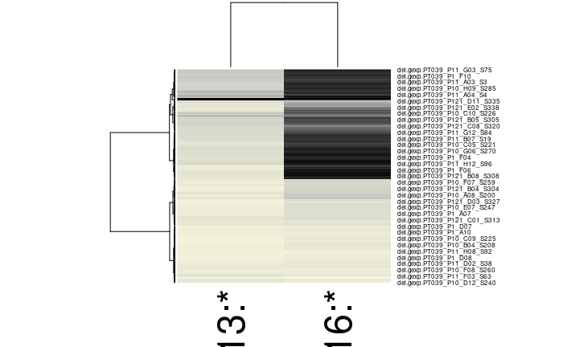

```r
trees <- hb$visualizeResults(geneBased=TRUE, alleleBased=FALSE, details=TRUE, margins=c(5,5))
```

We can again visualize our results, this time, ordering the cells based on their posterior probabilities of harboring CNVs.

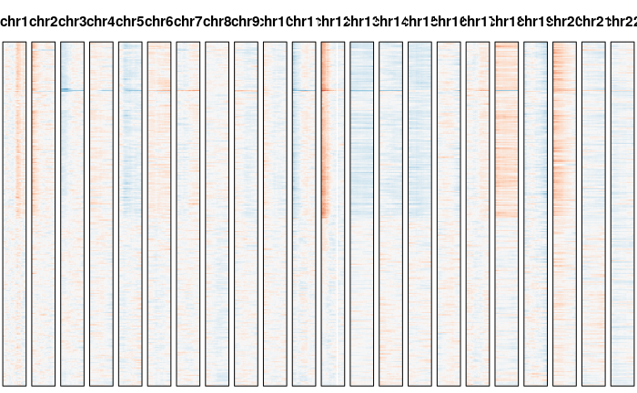

```r
## order cells
hc <- trees$hc
order <- hc$labels[hc$order]
## plot all chromosomes
hb$plotGexpProfile(cellOrder=hc$order)
```

We can compare this result with the one from the paper (Figure 2D,E):

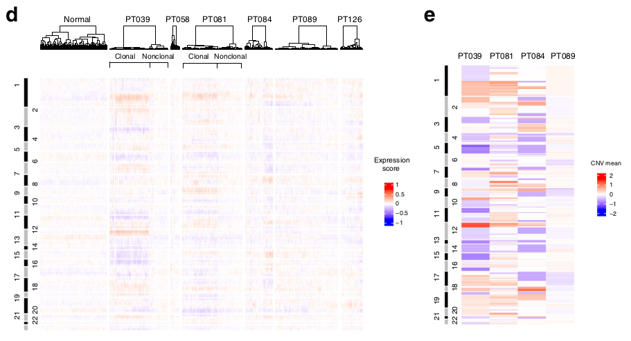

Karaayvaz 2018 2D,E

We observe also a highlighted amplification in chr12, that was later confirmed by WES (Figure 2E)

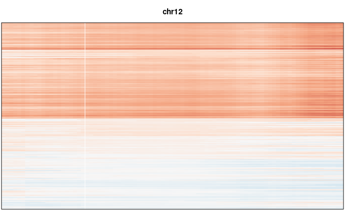

```r
## plot just identified cnvs
hb$plotGexpProfile(cellOrder=hc$order, region=hb$cnvs[['gene-based']][['amp']])
```

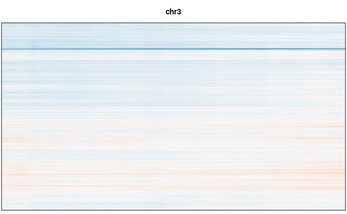

```r
hb$plotGexpProfile(cellOrder=hc$order, region=hb$cnvs[['gene-based']][['del']])
```

Finally, we can also visualize the results from HoneyBadger into our UMAPs.

```r
head(results)
```

|  | seqnames | start | end | width | strand | avg.amp.gexp | avg.del.gexp | PT039_P11_A01_S1 | PT039_P11_A02_S2 | PT039_P11_A03_S3 | PT039_P11_A04_S4 | PT039_P11_A07_S7 | PT039_P11_A09_S9 | PT039_P11_A11_S11 | PT039_P11_A12_S12 | PT039_P11_B02_S14 | PT039_P11_B03_S15 | PT039_P11_B04_S16 | PT039_P11_B05_S17 | PT039_P11_B06_S18 | PT039_P11_B07_S19 | PT039_P11_B08_S20 | PT039_P11_B09_S21 | PT039_P11_B10_S22 | PT039_P11_B11_S23 | PT039_P11_C03_S27 | PT039_P11_C05_S29 | PT039_P11_C06_S30 | PT039_P11_C07_S31 | … |
| --- | --- | --- | --- | --- | --- | --- | --- | --- | --- | --- | --- | --- | --- | --- | --- | --- | --- | --- | --- | --- | --- | --- | --- | --- | --- | --- | --- | --- | --- | --- |
| 1 | chr12 | 861759 | 33049774 | 32188016 | * | 0.51157784 | 0.00000000 | 0.27450 | 0.84625 | 0.85700 | 0.8225 | 0.1545 | 0.29175 | 0.65025 | 0.71375 | 0.77125 | 0.32800 | 0.8865 | 0.91975 | 0.22150 | 0.86425 | 0.86800 | 0.30425 | 0.12575 | 0.21800 | 0.89075 | 0.91750 | 0.38575 | 0.9455 | … |
| 2 | chr2 | 75873909 | 242668893 | 166794985 | * | 0.03498901 | 0.01606502 | 0.04475 | 0.04600 | 0.02875 | 0.0080 | 0.0130 | 0.00400 | 0.05325 | 0.04650 | 0.10550 | 0.01575 | 0.0355 | 0.01875 | 0.04025 | 0.05050 | 0.09375 | 0.00550 | 0.01800 | 0.04025 | 0.05300 | 0.04775 | 0.03225 | 0.0720 | … |
| 3 | chr3 | 3168600 | 81811312 | 78642713 | * | 0.00000000 | 0.18312363 | 0.00000 | 0.00000 | 0.00000 | 0.0000 | 0.0000 | 0.00000 | 0.00000 | 0.00000 | 0.00000 | 0.00000 | 0.0000 | 0.00000 | 0.00000 | 0.00000 | 0.00000 | 0.00000 | 0.00000 | 0.00000 | 0.00000 | 0.00000 | 0.00000 | 0.0000 | … |

```r
prob_res<- data.frame(t(results[,8:ncol(results)]))
colnames(prob_res)<- paste0("prob_", results$seqnames, "_", results$start, "_", results$end)
length(intersect(rownames(prob_res), rownames(sce_cells_umap)))
```

```
[1] 273
```

```r
sce_cells_umap<- cbind(sce_cells_umap,prob_res[rownames(sce_cells_umap),])
head(sce_cells_umap)
```

|  | UMAP1 | UMAP2 | patient | plate | well | cell | prob_chr12_861759_33049774 | prob_chr2_75873909_242668893 | prob_chr3_3168600_81811312 |
| --- | --- | --- | --- | --- | --- | --- | --- | --- | --- |
| PT089_P1_A01 | 0.5538283 | 5.460897 | PT089 | P1 | A01 | epithelial | NA | NA | NA |
| PT089_P1_A02 | 0.4698032 | 5.313827 | PT089 | P1 | A02 | epithelial | NA | NA | NA |
| PT089_P1_A03 | 0.4478316 | 5.291798 | PT089 | P1 | A03 | epithelial | NA | NA | NA |
| PT089_P1_A04 | 7.4599853 | -4.104423 | PT089 | P1 | A04 | macrophage | NA | NA | NA |
| PT089_P1_A05 | 7.3335481 | -3.796718 | PT089 | P1 | A05 | macrophage | NA | NA | NA |
| PT089_P1_A06 | 0.4591347 | 5.320779 | PT089 | P1 | A06 | epithelial | NA | NA | NA |

```r
NA
```

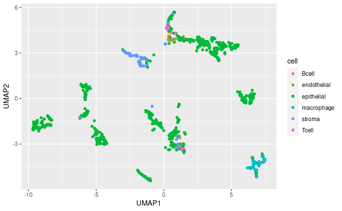

```r
ggplot(sce_cells_umap, aes(UMAP1, UMAP2, color=cell) )+
  geom_point()
```

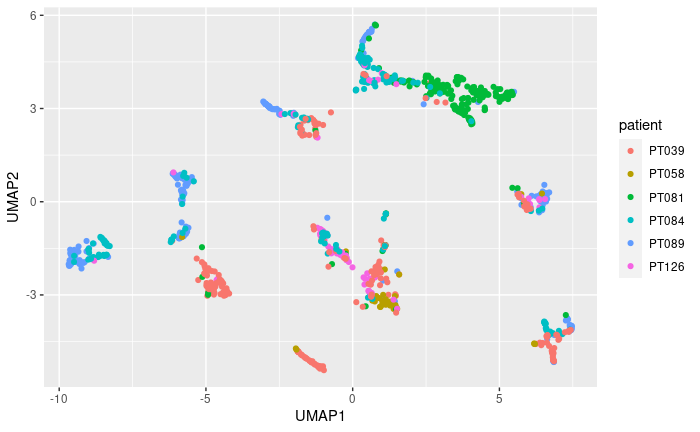

```r
ggplot(sce_cells_umap, aes(UMAP1, UMAP2, color=patient) )+
  geom_point()
```

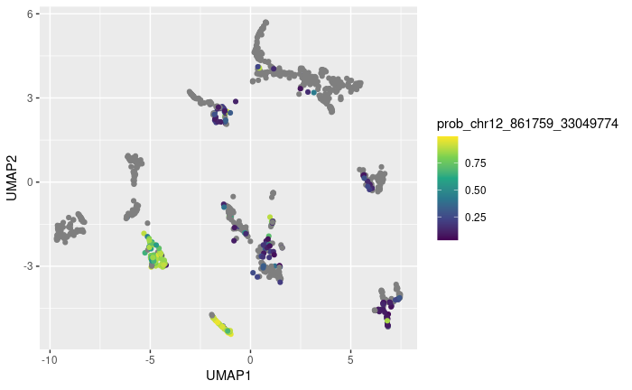